# Final Project - Part 1

### In this part we will perform exploration of two data sets:

## **1. Covid Concern**

This data set is the result of a poll conducted at the US during the covid outbreak period.  
it describes the level of concern of the US citizens separated by their Political polarization.  
at first we will read the csv given in the project instructions:

we can see that the data set contains 4 columns and 41 rows. the type of the date column is character , we need it to be date :

```
## Rows: 41
## Columns: 4
## $ date <date> 2020-02-25, 2020-02-26, 2020-02-27, 2020-02-28, 2020-02-29, 2020~
## $ dem  <dbl> 35, 35, 35, 35, 36, 37, 37, 37, 38, 39, 39, 41, 43, 46, 49, 52, 5~
## $ rep  <dbl> -57, -58, -58, -58, -58, -58, -57, -56, -56, -56, -56, -56, -54, ~
## $ diff <dbl> 92, 93, 93, 93, 94, 95, 94, 93, 94, 95, 95, 97, 97, 97, 97, 96, 9~
```

Explanation of the columns:

| Column Name | Type | Description |
| --- | --- | --- |
| date | date | the date the citizens report their concern |
| dem | double | the concern level of the democrats |
| rep | double | the concern level of the republicans |
| diff | double | the difference between their concerns |

In order to understand our data we chose to explore interesting statistics on the data:

```
##        Democrats Republicans Difference
## MAX     82.00000    23.00000   97.00000
## MIN     35.00000   -58.00000   59.00000
## MEDIAN  66.00000   -21.00000   87.00000
## MEAN    60.29268   -20.85366   81.14634
## SD      18.05304    31.49648   14.17844
```

### Plotting the data :

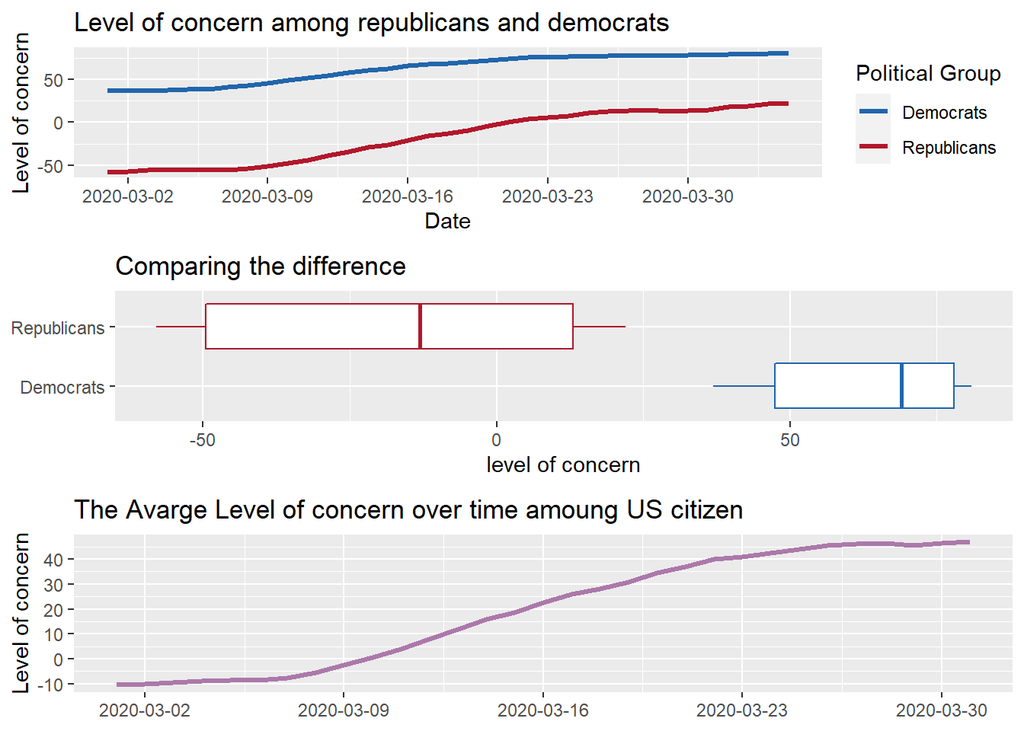

*Explanation: It seems that there is a clear difference in the concern between the republicans and democrats. while the republicans had negative concern at March (meaning they werent concerned of the covid) and the concern seems to rise as the months goes by. the democrats on the other hand had positive concern all the covid period.The conclusion is that the chage in the concern of the republicans wes much higher than the democrats.*

## **2. Covid Cases**

This data set presents actual information on the US patients status at each date since the beginning of covid outbreak in the US. The data is separated by dates, states and directions. at the right side of each month table there is a summarize table of all deaths,recovered and confirmed patients.  
This data set was given to us as a wikipedia page so at first we will read it and set it as data frame

```r
dim(wiki_table)
```

```
## [1] 337  64
```

As we can see this data set contains 64 columns and 337 rows.  
the data is not organized and the data types are not usable.  
so before we explore this data we need to clean and organize it:

*Explanation: we cleaned the data from commas and unwanted signs , we set the data column to be of date data type and all other columns to be of numeric type.  
we chose to separate the data to 3 tables -  
1. wiki_table - the entire data from the wikipedia page.

```r
head(wiki_table,2)
```

```
##   Date_Date West_AK West_AZ West_CA West_CO West_HI West_MT West_NM West_NV
## 2 21-Jan-20
## 3 24-Jan-20
##   West_OR West_UT West_WA West_WY West_IA Midwest_IL Midwest_IN Midwest_KS
## 2                               1
## 3                                                             1
##   Midwest_MI Midwest_MN Midwest_MO Midwest_ND Midwest_NE Midwest_OH Midwest_OK
## 2
## 3
##   Midwest_SD Midwest_WI Midwest_AL South_AR South_FL South_GA South_KY South_LA
## 2
## 3
##   South_MS South_NC South_SC South_TN South_TX South_VA South_WV South_CT
## 2
## 3
##   Northeast_DC Northeast_DE Northeast_MA Northeast_MD Northeast_ME Northeast_NH
## 2
## 3
##   Northeast_NJ Northeast_NY Northeast_PA Northeast_RI Northeast_VT Northeast_GU
## 2
## 3
##   Territories_MP Territories_PR Territories_VI Territories_Date Date_Date
## 2                                                               21-Jan-20
## 3                                                               24-Jan-20
##   Confirmed_Daily Confirmed_Total Deaths_Daily Deaths_Total Recovered_Daily
## 2               1               1
## 3               1               2
##   Recovered_Total Active_Total
## 2                            1
## 3                            2
```

2.wiki_confirmed - only the data about the confirmed patients separated by states.

```
## Rows: 17,545
## Columns: 4
## $ Date_Date <date> 2020-01-24, 2020-01-24, 2020-01-24, 2020-01-24, 2020-01-24,~
## $ region    <chr> "West", "West", "West", "West", "West", "West", "West", "Wes~
## $ state     <chr> "AK", "AZ", "CA", "CO", "HI", "MT", "NM", "NV", "OR", "UT", ~
## $ amount    <dbl> 0, 0, 0, 0, 0, 0, 0, 0, 0, 0, 0, 0, 0, 0, 1, 0, 0, 0, 0, 0, ~
```

3.wiki_summary - the summarized data about deaths , recovered and confirmed patients for all the states in the data.*

```
## Rows: 319
## Columns: 8
## $ Date_Date       <date> 2020-01-24, 2020-01-25, 2020-01-26, 2020-01-30, 2020-~
## $ Confirmed_Daily <dbl> 1, 1, 2, 1, 1, 1, 3, 1, 0, 2, 0, 1, 0, 4, 5, 18, 15, 2~
## $ Confirmed_Total <dbl> 2, 3, 5, 6, 7, 8, 11, 12, 12, 14, 14, 15, 15, 19, 24, ~
## $ Deaths_Daily    <dbl> 0, 0, 0, 0, 0, 0, 0, 0, 0, 0, 0, 0, 0, 0, 1, 1, 4, 3, ~
## $ Deaths_Total    <dbl> 0, 0, 0, 0, 0, 0, 0, 0, 0, 0, 0, 0, 0, 0, 1, 2, 6, 9, ~
## $ Recovered_Daily <dbl> 0, 0, 0, 0, 0, 0, 0, 0, 3, 2, 1, 0, 0, 0, 1, 2, 0, 0, ~
## $ Recovered_Total <dbl> 0, 0, 0, 0, 0, 0, 0, 0, 3, 5, 6, 6, 6, 6, 7, 9, 9, 9, ~
## $ Active_Total    <dbl> 2, 3, 5, 6, 7, 8, 11, 12, 9, 9, 8, 9, 9, 13, 16, 31, 4~
```

before starting to plot the data we decided to explore interesting statistics on the data:

```
##        Confirmed_Daily Deaths_Daily Recovered_Daily
## MAX        226197.0000    3331.0000     200852.0000
## MIN             0.0000       0.0000          0.0000
## MEDIAN      40171.0000     909.0000      30601.0000
## MEAN        58270.1661    1003.5235      37130.0063
## SD          56036.1225     730.3567      38226.7906
```

### Plotting the data :

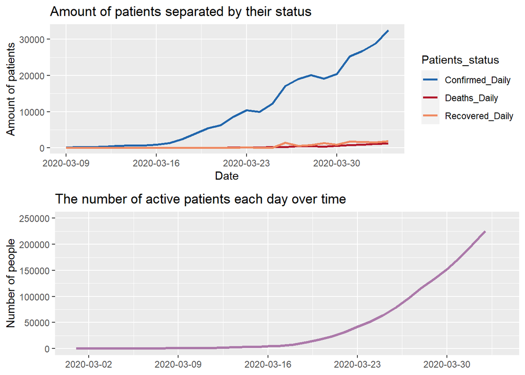

After Exploring those two data sets we thought they can be more useful to our research if we combine them together , we found a third data set that gives us information about the political party of each state. the division into states was determined by election to the presidency

```
## # A tibble: 50 x 10
##    State `2020 president~ Governor `State Senate` `State House` `SeniorU.S. Sen~
##    <chr> <chr>            <chr>    <chr>          <chr>         <chr>
##  1 Alab~ Republican       Republi~ Republican 27~ Republican 7~ Republican
##  2 Alas~ Republican       Republi~ Republican 13~ Coalition 23~ Republican
##  3 Ariz~ Democratic       Republi~ Republican 16~ Republican 3~ Democratic
##  4 Arka~ Republican       Republi~ Republican 28~ Republican 7~ Republican
##  5 Cali~ Democratic       Democra~ Democratic 31~ Democratic 5~ Democratic
##  6 Colo~ Democratic       Democra~ Democratic 20~ Democratic 4~ Democratic
##  7 Conn~ Democratic       Democra~ Democratic 24~ Democratic 9~ Democratic
##  8 Dela~ Democratic       Democra~ Democratic 14~ Democratic 2~ Democratic
##  9 Flor~ Republican       Republi~ Republican 24~ Republican 7~ Republican
## 10 Geor~ Democratic       Republi~ Republican 34~ Republican 1~ Democratic
## # ... with 40 more rows, and 4 more variables: JuniorU.S. Senator <chr>,
## #   U.S. House of Representatives <chr>,
## #   Party registration or identification (% as of 2020[update]) <chr>,
## #   short_state <chr>
```

we can see this data set contains 10 columns and 50 rows. we only care about 3 columns - State,2020 presidential election,short_state. so we will arrange the data for it.

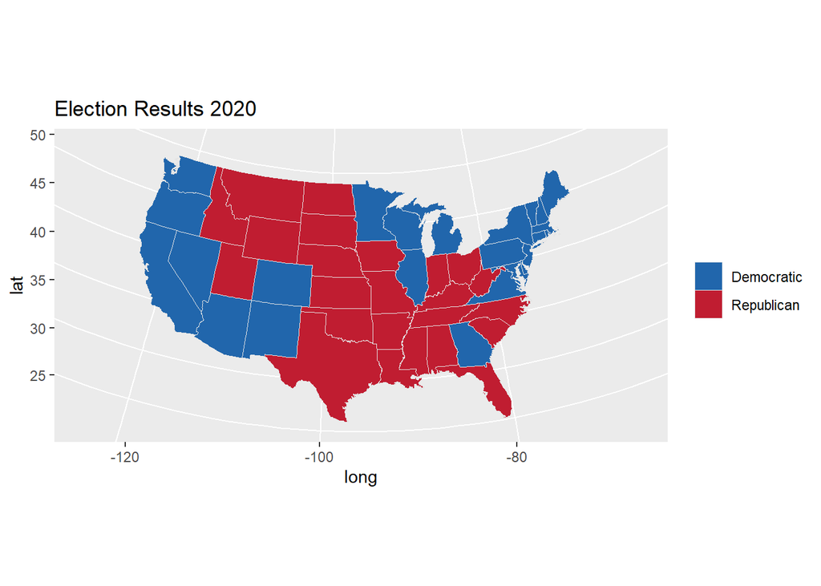

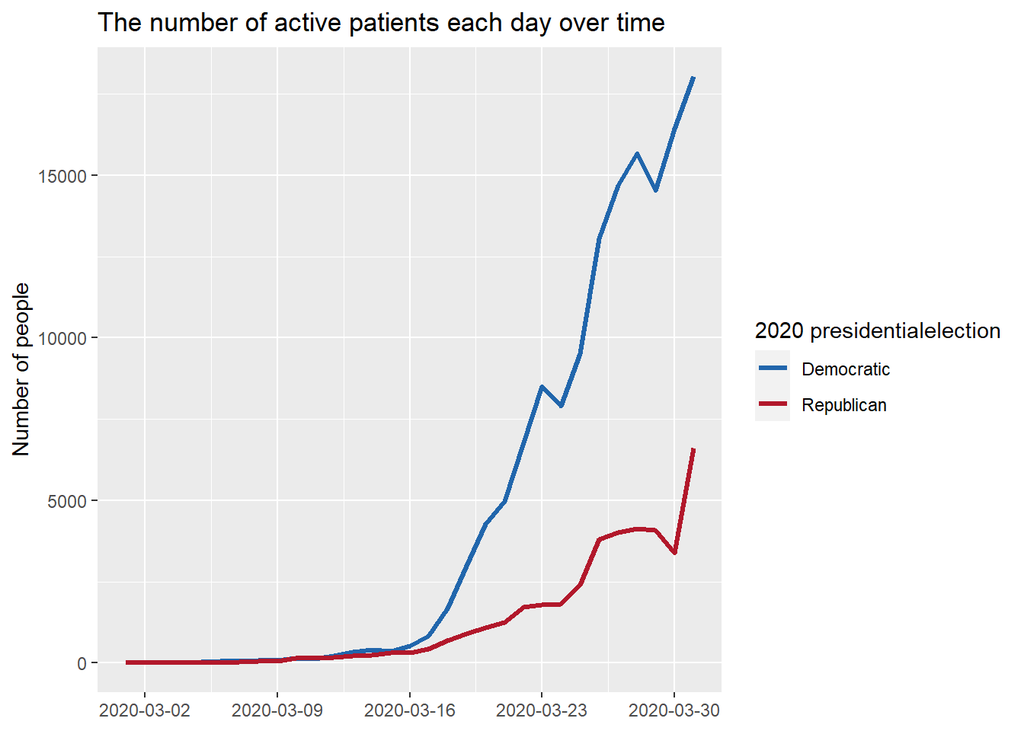

## Summarize:

After reading , cleaning and studding those two data sets we chose to explore the connection between them:

Statistics: get the 3 states who had the maximum amount of daily confirmed

```
##    state amount
## 41    PA  10482
## 37    NY   4305
## 28    MS   2726
```

1. In Israel the panic started when the number of daily patients crossed the 1000 patients, lets see if US had the same affect:

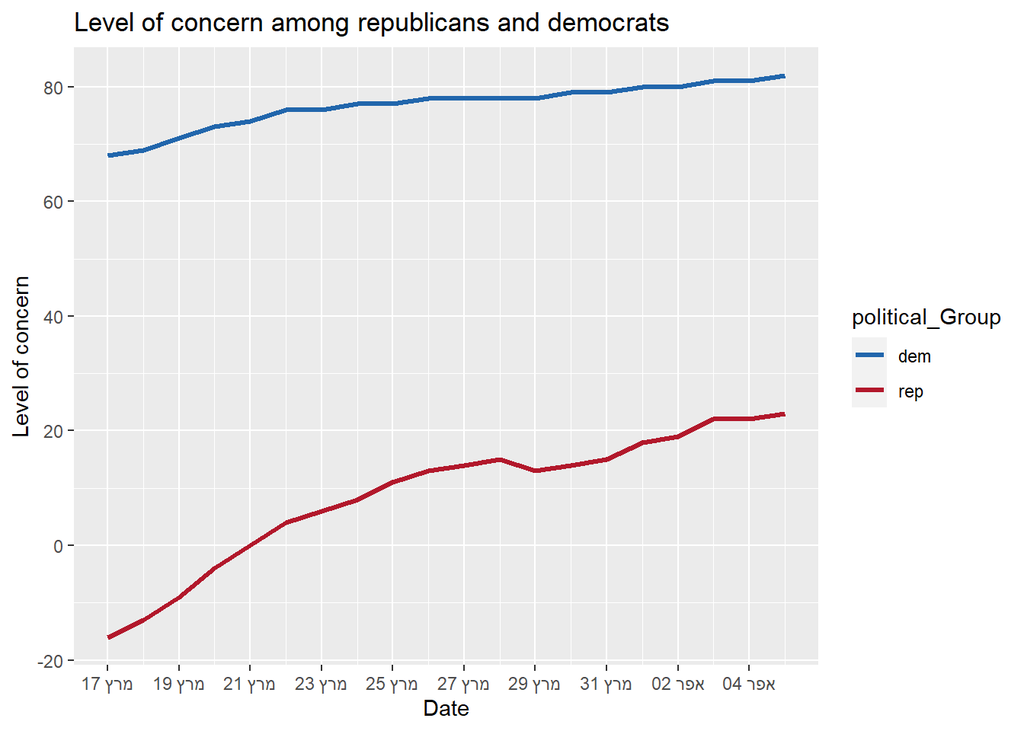

*Explanation:We wanted to see if the number of confirmed patients affected the concern of the citizens. we checked when the number of daily confirmed patients crossed the 1000 patient - found it was on March 17. We can see from the plot that around those dates the concern has increased especially at the republican who were not concerned at all, their concern raised from negative to positive only a few days after the patients number crossed the 1000.*

which state had the highest number of confirmed patients that day

```
##    state amount
## 41    PA    424
## 55    WY    108
## 37    NY     87
```

*Explanation:we saw that on March 17 when the total daily confirmed patients number went above the 1000 patients , the republicans are starting become more concerned. we can see that on that on this date the 3 states who has the highest of confirmed patients are Pennsylvania,Wyoming and New York. Wyoming is the only republican state from those 3 which can explain the rise at their concern. Another interesting thing we found is that above its hard hit from covid Pennsylvania was known as a state who had a lot of young covid patients, this information can affect the concern of the USA citizens.*

2.we can look at this from the other direction, we can see that the Republican concern has gone from negative to positive on March 21, lets take a look what happened on that date in covid cases:

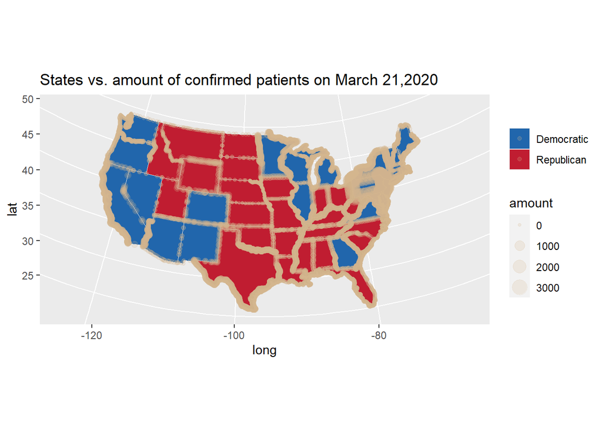

*Explanation:We wanted to see if the sudden increase in the republicans concern was affected by the amount of confirmed patients in the states where the republicans are the majority. we checked the amount of each state on March 21.In this plot the color of the state represents the political party and the circles are representing the amount of confirmed patients sized by the amount. We can see from the plot something very surprising - the republican states has lower amount than that of the democrats states. a possible explanation for this is that the pandemic began in New York which as we can see is almost covered entirely with circles. it was only after the poll was taken that the pandemic was spread all over the USA.*

3.explore the difference the the level of concern over time: **note - as explained before - the diff value in the poll data set represents the daily difference between the republicans concern and the democrats concern.

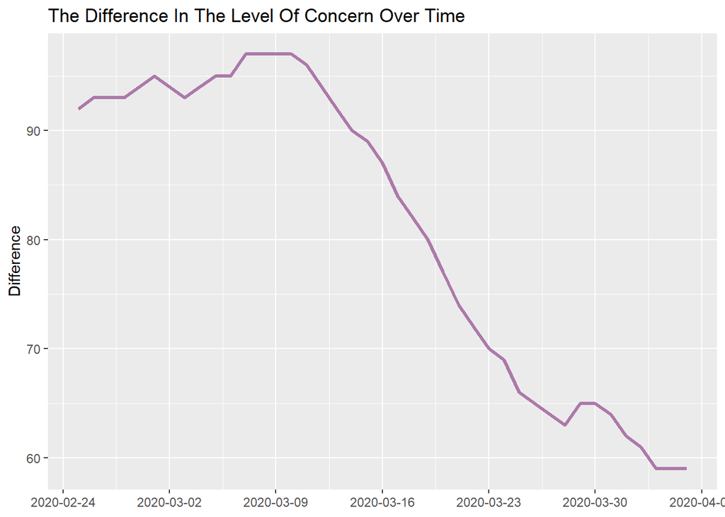

we can see that the highest difference is at March 9, lets take a look what happens in terms of confirmed patients :

```
##    state amount
## 41    PA     36
## 55    WY     26
## 5     CA     19
```

```
##   Confirmed_Daily Deaths_Daily Recovered_Daily
## 1             148            5               0
```

*Explanation:We wanted to see if the maximum difference in the concern was affected by the amount of confirmed deaths and recovered patients. we checked the amount of each state on March 9. Another interesting about this date which can affect the concern of the USA citizens is that on that date the stock market crashed*